# Calculating a time series of diversification rates in a time-calibrated molecular phylogeny

I want to describe the calculation of timeseries of diversification rates that I used in Simpson et al. (2011) and Simpson (2013).

The basic method is simple and there is a function for calculating the rate estimate and likelihood in a specified window of time in the laser package by Rabosky: `yule.Window()`. But there are a couple of tricks to using it effectively, especially if you want to use an arbitary timescale.

```r
# This is yuleWindow from laser. But importantly, I've commented out the text
# outputs. This speeds things up and makes this document shorter.

yuleWindow <- function (x, st1 = x[1], st2 = 0)
{
    checkbasal(x)
    if (!is.numeric(x))
        stop("object x not of class 'numeric'")
    if (st1 <= st2) {
        cat("Error: invalid input\n\n")
        cat("shift points must be in temporal order (first, second)\n")
        cat("and in units of time/substitutions before present\n\n")
        return()
    }
    x <- rev(sort(x))
    res <- as.list(yuleint2(x, st1, st2))
    if (is.na(res$LH)) {
        print("Error.  Must be >= 1 speciation event within temporal window\n")
        stop()
    }
   # cat("---------------------------------\n")
    #cat("Results of fitting Yule model to temporal window of \n")
    #cat("(", st1, ",", st2, ") time units before present:\n\n")
    #cat("ML speciation rate: ", res$smax, "\n\nLikelihood: ",
    #    res$LH, "\n\n")
    return(res)
}
```

Tanja Stadler published a similar method (Stadler 2011 and the package `TreePar`) that allows rates to change from interval to interval only if the likelihood in that interval exceeds a certain threshold defined by a constant rate. We know from the fossil record that rates are never constant, so having a null that is constant just does not make sense to me. However, you can easily test for that with the code here by saving the likelihoods.

For a single simulated tree:

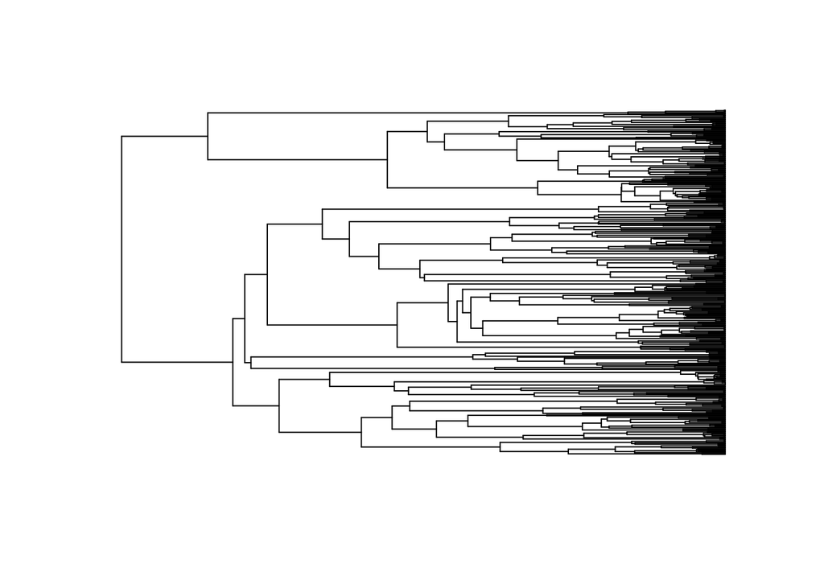

```r
library(ape)

b <- 0.2
d <- 0.1
C <- 10
R <- 1
tree <-rbdtree(b, d, Tmax = 50)
plot(tree, show.tip.label = F)
```

You don’t even need a real time scale. In the example below, the scale is simply a window 1.5 million years wide sliding every 1 million years. Now with this kind of timescale there are two options that become important. 1) the width of the window (`w`), and 2)the minimum number of nodes in the window you want to calculate rates on (`n`). These two paramters interact with each other, the wider the window the easier it is to get lots of nodes. All of this is not important if you use a geological time scale and multiple trees pulled from the posterior of a Bayesian analysis.

The basic code is with an arbitrary timescale is:

```r
suppressMessages(library(laser))

max.t <- max(branching.times(tree))


t <- max.t:1
div <- as.numeric()
lik <- as.numeric()

w=1.5
# w is the width of the window. This can be adjusted. Wider windows will
# natrually include more nodes and give a better estimate of the diversification
# rates.

n=1
# n is the minimum number of nodes needed in a window. This needs to be larger
# than 0, but as small as possible



  bt.tree<-branching.times(tree)

for(i in t){
  a <- length(which(bt.tree > t[i] & bt.tree < t[i]+w)  )
  if(a > n){
    yw <- try(yuleWindow(bt.tree, st1=t[i]+w, st2=t[i]))
    div[i] <- yw$smax
    lik[i] <- yw$LH

    } else{div[i]<-NA
           lik[i] <- NA}
}
```

The diversification rates are saved in `div` and the likelihoods are in `lik`.

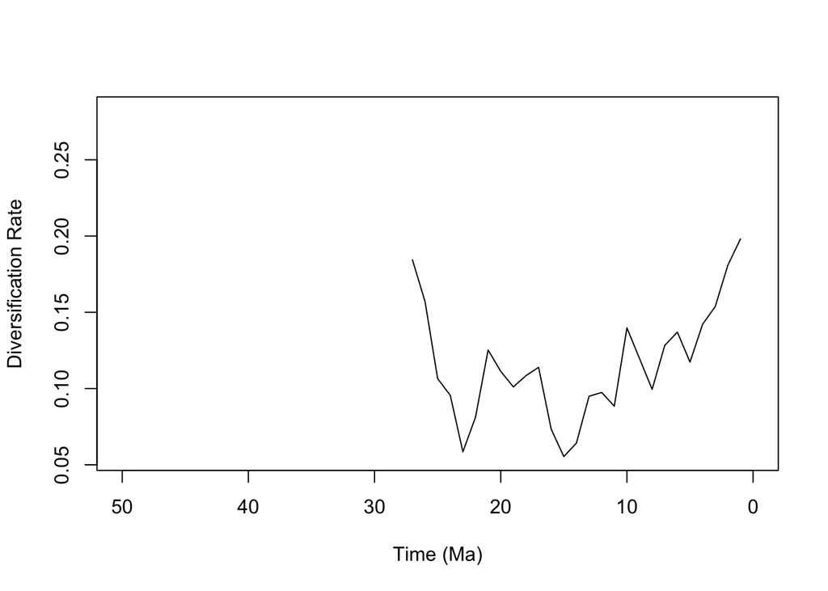

```r
plot(t, div, type = 'l', xlim = c(50,0), xlab = "Time (Ma)", ylab = "Diversification Rate")
```

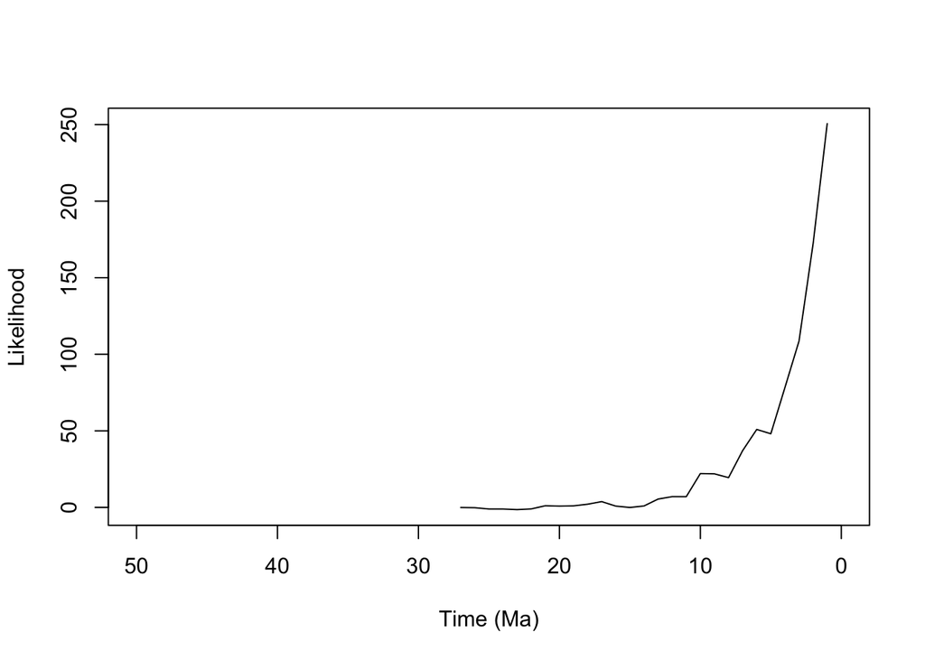

```r
plot(t, lik, type = 'l', xlim = c(50,0), xlab = "Time (Ma)", ylab = "Likelihood")
```

## Adding a geological timescale

This is how I prefer to do things.

First I define the time scale. Usually I keep a csv file with the timescale and source it.

```r
#Cenozoic timescale
tscale.bot <- c(66, 61.6,59.2, 56, 47.8,
                41.2,37.8, 33.9,
                28.1,23.0, 20.4,
                16.0, 13.8, 11.6,
                7.2, 5.3, 3.6, 2.6, 1.8, 0.01)
tscale.top <- c(tscale.bot[-1], 0)

tscale <- cbind(tscale.bot, tscale.top, tscale.top + (tscale.bot-tscale.top)/2)
tscale
```

```
##       tscale.bot tscale.top
##  [1,]      66.00      61.60 63.800
##  [2,]      61.60      59.20 60.400
##  [3,]      59.20      56.00 57.600
##  [4,]      56.00      47.80 51.900
##  [5,]      47.80      41.20 44.500
##  [6,]      41.20      37.80 39.500
##  [7,]      37.80      33.90 35.850
##  [8,]      33.90      28.10 31.000
##  [9,]      28.10      23.00 25.550
## [10,]      23.00      20.40 21.700
## [11,]      20.40      16.00 18.200
## [12,]      16.00      13.80 14.900
## [13,]      13.80      11.60 12.700
## [14,]      11.60       7.20  9.400
## [15,]       7.20       5.30  6.250
## [16,]       5.30       3.60  4.450
## [17,]       3.60       2.60  3.100
## [18,]       2.60       1.80  2.200
## [19,]       1.80       0.01  0.905
## [20,]       0.01       0.00  0.005
```

Then I run the rate calculation.

```r
suppressMessages(library(laser))
div <- as.numeric()

# n=0   # n is the minimum number of nodes needed in a window.
# This needs to be larger than 0, but as small as possible

  bt.tree<-branching.times(tree)

  for(i in 1:length(tscale[,1])){
    a <- length(which(bt.tree > tscale[i,2] & bt.tree < tscale[i,1]))
    if(a > n){
      div[i] <- try(yuleWindow(bt.tree, st1=tscale[i,1], st2=tscale[i,2])$smax)
    } else{div[i]<-NA
           }
  }
```

After running the calculation, I plot it…

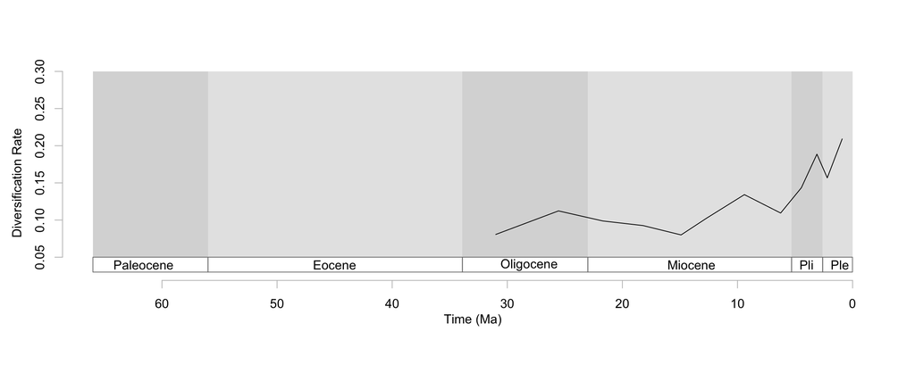

```r
plot(tscale[,3], div,
     type = 'n',
     xlim = c(66,0),
     ylim = c(0, 0.3),
     xlab = "", ylab = "",
     axes = F)
# draw timescale in background

bases <- c(66, 56, 33.9, 23.0, 5.3, 2.6, 0.01,0.01)
cc<-rep(c("grey85","grey90"),11)

bt <- 0.05; to <- 0.3
for (b in 1:16) rect(xleft=bases[b], ybottom=bt,
                     xright=bases[b+1], ytop=to,col=cc[b], border=NA)

# add ribbon of time scale
 bt <- 0.03; to <- 0.05
 # Add boxes  for legend of time
  for (b in 1:6) rect(xleft=bases[b], ybottom=bt,
                      xright=bases[b+1], ytop=to,col=NA,border='grey50')

# Add Text for legend of time
    bt <- (bt+to)/2 # Level of text
    tpl <- c(61.6, 45, 28.1, 14, 4, 1.1)
    tx <- c( "Paleocene", "Eocene", "Oligocene", "Miocene", "Pli", "Ple")

for (t in 1:6) text(x=tpl[t], y=bt, labels=tx[t])

axis(1, col = "grey75", line = -1.5)
mtext("Time (Ma)", side = 1, line = 0.5)
axis(2, col = "grey75", line = 0, at = c(0.05, 0.1, 0.15, 0.2, 0.25, 0.3))
mtext("Diversification Rate", side = 2, line = 2.5)

# plot lines
lines(tscale[,3], div)
```

In the background of this plot I show epoch-level geological time. Also, I usually use a function for plotting these timescales in the background.

## References

Rabosky, Daniel L. “LASER: a maximum likelihood toolkit for detecting temporal shifts in diversification rates from molecular phylogenies.” Evolutionary Bioinformatics Online 2 (2006): 247.

Simpson, Carl, et al. “Evolutionary diversification of reef corals: a comparison of the molecular and fossil records.” Evolution 65.11 (2011): 3274-3284.

Simpson, Carl. “Species selection and the macroevolution of coral coloniality and photosymbiosis.” Evolution 67.6 (2013): 1607-1621.

Stadler, Tanja. “Mammalian phylogeny reveals recent diversification rate shifts.” Proceedings of the National Academy of Sciences 108.15 (2011): 6187-6192.